```python
import analysis as a
import metric_functions as mf
```

# Report on the Segregation of Cities

### Measures and their formulas used to compare segregation among the cities:

MEASURES OF EXPOSURE -

“Exposure measures the degree of potential contact, or possibility of interaction, between minority and majority group members” (Massey and Denton, p. 287). The two basic measures of exposure are interaction and isolation. Interaction measures the probability that a minority person shares a unit area with a majority person, whereas isolation measures the probability that a minority person shares a unit area with another minority person.

\begin{equation*} \sum_{i=1}^{n}[( \frac{x_i}{X}) \frac{y_i}{t_i})] \end{equation*}

*Interaction Formula*

\begin{equation*} \sum_{i=1}^{n}[( \frac{x_i}{X}) \frac{x_i}{t_i})] \end{equation*}

*Isolation Formula*

[figure not shown]

```python
table_1 = a.mf.int_iso_cor_df(a.cities, a.cities_dfs)
table_1 = table_1.sort_values('interaction')

a.mf.int_iso_plot_fun(table_1, a.cities)
```

> In the following table are the exact values, ordered by lowest to highest level of interaction:

```python
table_1
```

|  | cities | interaction | isolation |
| --- | --- | --- | --- |
| 0 | baltimore | 0.216858 | 0.775621 |
| 2 | chicago | 0.336096 | 0.663751 |
| 8 | milwaukee | 0.404119 | 0.595755 |
| 11 | st_louis | 0.418878 | 0.579255 |
| 7 | memphis | 0.481029 | 0.518798 |
| 4 | dayton | 0.506107 | 0.492699 |
| 1 | charleston | 0.517727 | 0.481825 |
| 3 | columbus | 0.535019 | 0.462473 |
| 6 | kc | 0.580335 | 0.419322 |
| 10 | pittsburgh | 0.602745 | 0.397029 |
| 12 | syracuse | 0.605775 | 0.393819 |
| 9 | ok_city | 0.612598 | 0.386369 |
| 13 | wichita | 0.638073 | 0.360383 |
| 5 | denver | 0.684396 | 0.314614 |

As you can see, isolation and interaction indexes sum to 1.0, however, this only is possible when there are two groups. It will not sum to 1.0 when there are more than two groups. Furthermore, the interaction indexes will only be equal when "two groups constitute the same proportion of the population".

Controlling for this assymetry by adjusting the isolation gives the correlation ratio, a third exposure index.

\begin{equation*} \frac{(I-P)}{(1-P)} \end{equation*}

*Correlation Formula*

```python
a.correlation_df
```

|  | baltimore | charleston | chicago | columbus | dayton | denver | kc | memphis | milwaukee | ok_city | pittsburgh | st_louis | syracuse | wichita |
| --- | --- | --- | --- | --- | --- | --- | --- | --- | --- | --- | --- | --- | --- | --- |
| 0 | 0.422077 | 0.229187 | 0.378244 | 0.247848 | 0.367634 | 0.131568 | 0.268904 | 0.391999 | 0.449833 | 0.144234 | 0.294292 | 0.445907 | 0.296762 | 0.188861 |

MEASURES OF EVENNESS -

Another great way to measure segregation across cities is to measure the evenness. This is used to compare the "spatial distributions of different groups among units in a metropolitan area". In this section of the report, I'll be using the Gini coefficient for this measurement. The formula for the Gini coefficient is as such:

\begin{equation*} \frac{ \sum_{i=1}^{n}\sum_{j=1}^{n}t_i t_j |(p_i - p_j)|}{2T^2P(1-P)} \end{equation*}

*Gini Formula*

The Gini coefficient will allow us to take in to account the distribution among each census tract without the results being influenced by possible extremes present in the data, which would affect the results if we used standard deviation.

> In the table below we see that Oklahoma City (*ok_city*) has a very low difference in the Gini coefficient values for their white and non white population (0.001). The next city with the lowest value is Chicago, with a value about 36 times that of Oklahoma City (0.05). The city with the highest difference between Gini values is Memphis, with a difference of nearly .3.

```python
a.gini_df
```

|  | cities | gini_diff | nw_gini | w_gini |
| --- | --- | --- | --- | --- |
| 9 | ok_city | 0.001284 | 0.358547 | 0.359831 |
| 2 | chicago | 0.046615 | 0.406454 | 0.453069 |
| 3 | columbus | 0.050217 | 0.417549 | 0.367333 |
| 6 | kc | 0.080201 | 0.438258 | 0.358058 |
| 1 | charleston | 0.096372 | 0.429386 | 0.333014 |
| 13 | wichita | 0.116424 | 0.425867 | 0.309443 |
| 8 | milwaukee | 0.139299 | 0.518809 | 0.379510 |
| 0 | baltimore | 0.147961 | 0.398397 | 0.546358 |
| 4 | dayton | 0.194862 | 0.543072 | 0.348211 |
| 10 | pittsburgh | 0.195142 | 0.539118 | 0.343976 |
| 11 | st_louis | 0.198270 | 0.552653 | 0.354383 |
| 5 | denver | 0.218330 | 0.450753 | 0.232422 |
| 12 | syracuse | 0.234476 | 0.532121 | 0.297645 |
| 7 | memphis | 0.292998 | 0.601299 | 0.308301 |

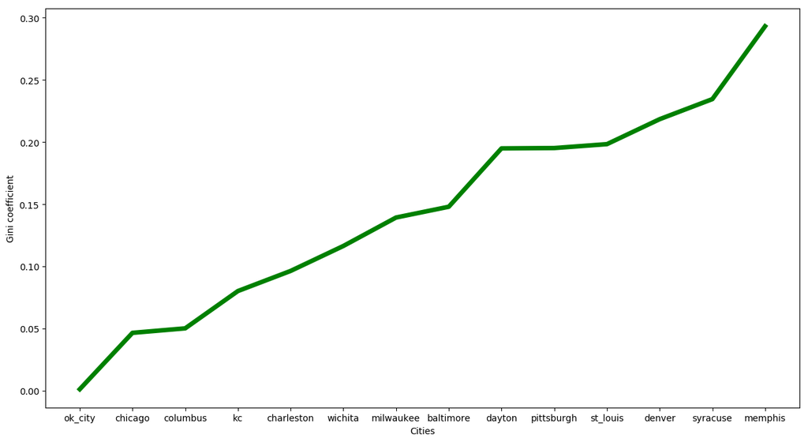

```python
a.gini_plot
```

> When using differences of standard deviation between white and non white populations among the 14 cities, we get very different results. Looking at these results, we see that Baltimore has the least difference between the two populations, with a very low number of 54.6 - for comparison, when using the Gini coefficient, Baltimore came with having the 8th largest difference. On the other hand, Memphis ranks at only 5 when using standard deviation to look at distribution.

```python
a.sd_df
```

|  | cities | sd_diff | sd_nw | sd_w |
| --- | --- | --- | --- | --- |
| 0 | baltimore | 54.580771 | 544.134295 | 489.553525 |
| 2 | chicago | 342.376581 | 1321.616172 | 1663.992754 |
| 5 | denver | 587.333680 | 773.736964 | 1361.070644 |
| 1 | charleston | 645.311696 | 1143.827944 | 1789.139640 |
| 7 | memphis | 676.291944 | 1157.325486 | 1833.617430 |
| 8 | milwaukee | 808.925064 | 991.488705 | 1800.413769 |
| 11 | st_louis | 910.420052 | 1226.426137 | 2136.846190 |
| 9 | ok_city | 962.149913 | 663.684001 | 1625.833913 |
| 3 | columbus | 1024.814585 | 1001.821289 | 2026.635874 |
| 4 | dayton | 1067.229376 | 838.469381 | 1905.698757 |
| 12 | syracuse | 1097.802392 | 558.087445 | 1655.889837 |
| 13 | wichita | 1137.956154 | 749.015688 | 1886.971842 |
| 10 | pittsburgh | 1157.208498 | 528.931684 | 1686.140182 |
| 6 | kc | 1317.753520 | 682.180712 | 1999.934231 |

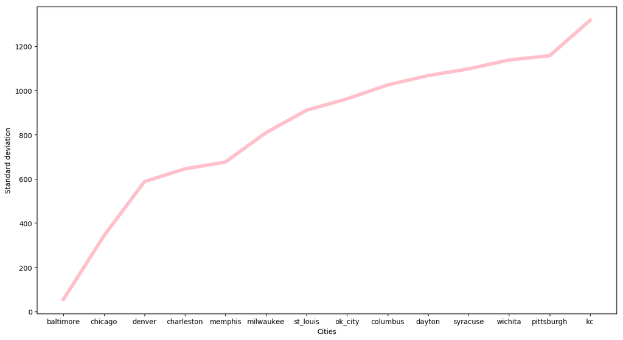

```python
a.sd_plot
```

> Since I want to compare the two visually, I'm going to multiply each Gini coefficient difference value by 4497.5 (this is taken from the highest standard deviation difference 1317.75 divided by the highest Gini coefficient difference 0.3). In the following visual we can see drastic differences in using the Gini coefficiet versus standard deviation to measure distribution among census tracts for most of the cities. Some of the cities yield similar results from the two measurements, such as St Louis and Syracuse.

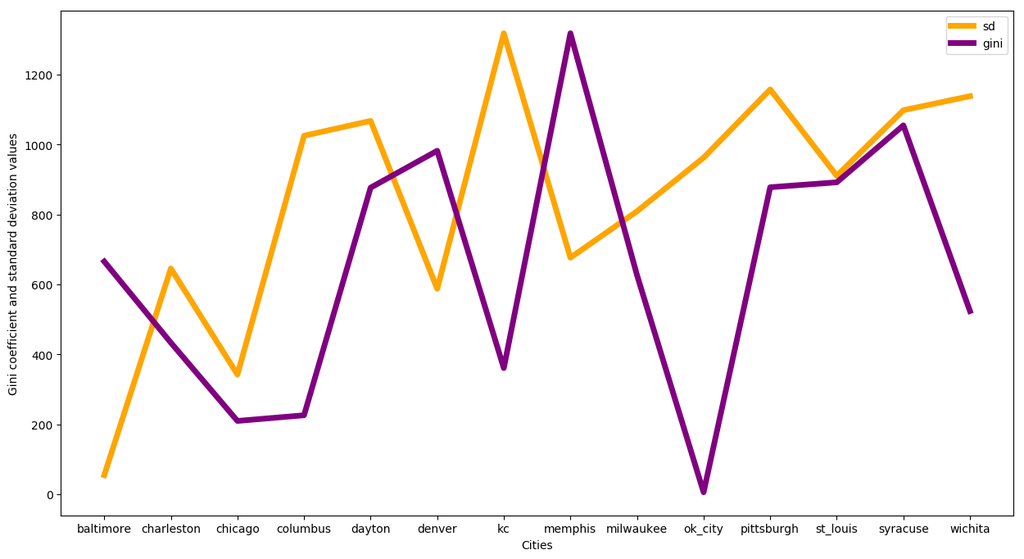

```python
a.sd_gini_plot
```

> In the following visualization, I compare the isolation to the non white Gini coefficient of each city. Some cities have quite a diffference - but overall they have similar results. We can see that in comparison to the Gini coefficient vs. standard deviation, the plot for isolation vs. the Gini coefficient are more alike.

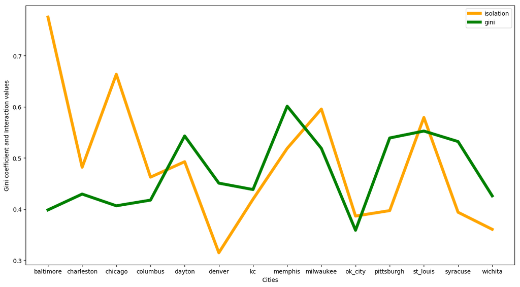

```python
a.iso_gini_plot
```

Overall both the Gini coefficient and the measures for isolation and interaction are valid and lead to an accurate and informative insight into segregation among census tracts for each of the cities. The Gini coefficient gives us a look into the distribution of racial groups among each census tract, whereas isolation, and it's counterpart interaction, tell us how isolated each city's racial groups are, and for the latter how much interaction there is. In my opinion the insights from both methods a valuable as the provide practical insight into the segregation found in cities.